# Covid_19 cases

## Visualizing Cases Over Time with Linear Regression Line

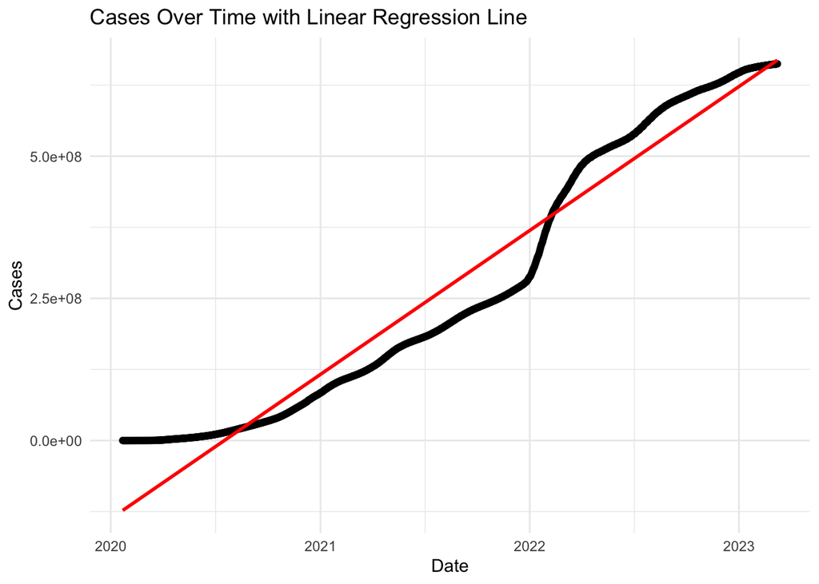

```r
ggplot(global_count, aes(x = date, y = cases)) +
  geom_point() +  # Add scatter plot points
  geom_smooth(method = "lm", se = FALSE, color = "red") +  # Add linear regression line
  labs(
    title = "Cases Over Time with Linear Regression Line",
    x = "Date",
    y = "Cases"
  ) +
  theme_minimal()
```

# Step 5 Identify Bias

Before starting this study, I believed that stricter contingency measures would always lead to lower mortality rates. However, this belief turned out to be incorrect. Now that I’ve reviewed the results, I understand that numerous other factors play a role. Disease spread is a complex issue influenced by social factors, and predicting anything related to human behavior is extremely challenging.

# Step 6 Conclusion

Another tricky part is that human behavior is a big factor. How people act, follow safety rules, and even how they go about their daily lives affects the disease. Predicting what people will do is really tough, like trying to find your way in a confusing maze. The study results have shown that because people act in unexpected ways, it’s hard to make exact models.

In the end, this study taught me that while rules do matter, there’s a lot more to consider. Everything happening around us, how people behave, and how society works all shape what happens with the disease. It’s like a big mix of things, and understanding it all is quite a challenge.